# CUE effect on SOM steady state with neglecting litter stock changes

## Summary

Extending CUEInspectMarkus2.Rmd for an explicit L pool.

Markus drew a up a simple SOM, $S$ and Microbial biomass, $B$, computed Steady state and inspected relationship of steady states stocks $S^*$ versus Carbon use efficiency (CUE), represented by parameter $\epsilon$.

With the simple model, $S^*$ increased as CUE decreased because fresh inputs accumulated and were only slowly decomposed.

Here I study a different system where I assume that the accumulation of litter inputs is not the primary determinant of SOM stocks.

## The model

There is a specific litter pool, that is assumed

- to be in quasi steady state (anyway when studying steady state),
- its changes in pool size are small compared to changes in pool size of the residue pool, $R$.

Hence here, litter inputs, $I$, directly feed to microbial biomass, $B$.

$$\begin{align}
dL/dt &= I -f_L(L)g(B) \\
dB/dt &= \epsilon f_L(L)g(B) + \epsilon f_R(R)g(B) - \tau B \\
dR/dt &= -f_R(R)g(B) + \tau B\\
\end{align}$$
where decomposition is a multiplicative function of stocks and microbial biomass, and a part $(1-\epsilon)$ is respired.

## Steady states

At steady state:
$$\begin{align}
f_L(L)g(B) &= I \\
dB/dt &= \epsilon I + \epsilon f_R(R)g(B) - \tau B \\
\end{align}$$

Steady state of $R$ by setting derivatives to zero and adding the equations of $dB$ and $dR$:
$$\begin{align}
0 &= \epsilon I + (\epsilon - 1) f_R(R^*)g(B^*) \\
f_R(R^*) &= \frac{\epsilon I}{(1-\epsilon) g(B^*)} \\
R^* &= f^{-1}\left( \frac{\epsilon I}{(1-\epsilon) g(B^*)} \right) \\
\frac{dR}{dt} &= (f^{-1})' \left( \frac{\epsilon I}{(1-\epsilon) g(B^*)} \right) \frac{\epsilon I}{(1-\epsilon)^2 g(B^*)}\\
\end{align}$$

With:
$$\begin{align}
y &= f_R(R) = k_R R \\
f^{-1}(y) &= y/k_R \\
(f^{-1})'(y) &= 1/k_R \\
R^* &= \frac{\epsilon I}{k_R (1-\epsilon) g(B^*)} \\
\end{align}$$
Steady state for Biomass B:
$$\begin{align}
0 &= \epsilon I +\epsilon \, k_R R^* g(B^*) - \tau B^* \\
0 &= \epsilon I + \epsilon \, k_R \frac{\epsilon I}{k_R (1-\epsilon) g(B^*)} g(B^*) - \tau B^* \\
0 &= \epsilon I + \epsilon \, \frac{\epsilon I}{(1-\epsilon) } - \tau B^* \\
B^* &= \left( 1 + \frac{\epsilon}{(1-\epsilon)} \right) \frac{\epsilon I}{\tau}
= \frac{\epsilon I}{\tau (1-\epsilon)} \\
\end{align}$$

$B^*$ does neither depend on dynamics of the litter pool nor on $k_R$ (as time is not important for staedy state) nor on $g(B)$.

With $g(B) = B/(k_M + B)$:
$$\begin{align}
R^* &= \frac{\epsilon I}{k_R (1-\epsilon) g(B^*)}
= \frac{\epsilon I}{k_R (1-\epsilon)} \frac{k_M+B^*}{B^*}\\
&= \frac{\epsilon I}{k_R (1-\epsilon)} \frac{k_M+\frac{\epsilon I}{\tau (1-\epsilon)}}
{\frac{\epsilon I}{\tau (1-\epsilon)}}
= \frac{k_M+ \frac{\epsilon I}{\tau (1-\epsilon)}}{k_R / \tau} \\
&= \frac{1}{k_R }\left( \tau k_M+ \frac{\epsilon I}{1-\epsilon} \right)\\
\end{align}$$
And with $f_L(L) = k_L L$:
$$\begin{align}
L^* &= f_L^{-1}\left( I / g(B^*) \right)
= \frac{I}{k_L} \frac{k_M+B^*}{B^*}\\
& = \frac{I}{k_L} \frac{k_M+\frac{\epsilon I}{\tau (1-\epsilon)}}{\frac{\epsilon I}{\tau (1-\epsilon)}}
= \frac{1}{k_L} \left( \frac{1-\epsilon}{\epsilon} k_m \tau + I \right) \\
\end{align}$$
On increasing $\epsilon$ the second input related term of $R^*$ increases. For $\epsilon \to 0$, $B^* \to 0$ and residue steady state stocks decrease towards a minimumm, but the litter stock will accumulate unlimited. For $\epsilon \to 1$, $B^* \to \infty$ but steady state stocks also increase unlimited, as there is no loss of carbon from the system.

Hence residue stocks always decrease with decreasing CUE. The balance of total SOM stocks will depend on the balance of increasing litter stock and decreasing residue stock. However, residue stocks and their changes are usually larger than changes in litter stocks. Moreover the balance between litter and residue is also be strongly controlled by their stoichiometry, e.g. their nitrogen contents.

### Minimum of SOM stocks

To compute the minimum of L+R stocks.
$$\begin{align}
R^* + L^* &= \frac{1}{k_R }\left( \tau k_M+ \frac{\epsilon I}{(1-\epsilon)} \right)+ \frac{1}{k_L} \left( \frac{1-\epsilon}{\epsilon} k_m \tau + I \right) \\
\end{align}$$

As a preparatory step, compute derivatives of the fractions:
$$\begin{align}
\left( \frac{\epsilon}{1-\epsilon} \right)' &= \frac{1}{(1-\epsilon)^2} \\
\left( \frac{1 -\epsilon}{\epsilon} \right)' &= -\frac{1}{\epsilon^2} \\
\end{align}$$
Next we find the $\epsilon$ for which the derivative in respect to $\epsilon$ is zero.
$$\begin{align}
(R^* + L^*)' &= \frac{1}{k_R }\left( \frac{I}{(1-\epsilon)^2} \right)
+ \frac{1}{k_L} \left( -\frac{1}{\epsilon^2} k_m \tau \right) \\
&= \frac{I}{k_R(1-\epsilon)^2} -\frac{k_m \tau}{k_L \epsilon^2} \\
0 &= I k_L \epsilon^2 - k_m \tau k_R(1-\epsilon)^2 = a \epsilon^2 - b(1-\epsilon)^2 \\
0 &= (a-b) \epsilon^2 +2b \epsilon -b \\
0 &= \epsilon^2 +2b(a-b) \epsilon -b/(a-b) = \epsilon^2 +p\epsilon -q \\
\epsilon_0 &= -\frac{p}{2} \pm \sqrt{\frac{p^2}{4}-q} = -\frac{p}{2} \pm \sqrt D\\
\end{align}$$
with
$$\begin{align}
a &= I \, k_L \\
b &= \tau k_M \, k_R \\
p &= 2 \tau k_M k_R / (I k_L - \tau k_M k_R) \\
q &= -\tau k_M k_R / (I k_L - \tau k_M k_R) \\
D &= \frac{p^2}{4}-q = \frac{\tau k_M k_R I k_L}{(I k_L - \tau k_M k_R)^2}
\end{align}$$
A minimum always exists, because always $D > 0$ for $a \ne b$. and for $a = b$, $\epsilon_0 = 0.5$. Only the positive solution ($+\sqrt{D}$) is a reasonable solution.

## Figures and numerical solution

The following plots show the relatinship between residue steady states and CUE. The red square denotes the state of a simulation of the model over 100 years. The gray dashed line denotes the CUE for which SOM stocks are minimal.

```
        I       tau        kR        kL        kM       eps
100.00000  12.00000   0.20000   5.00000  16.26984   0.40000
```

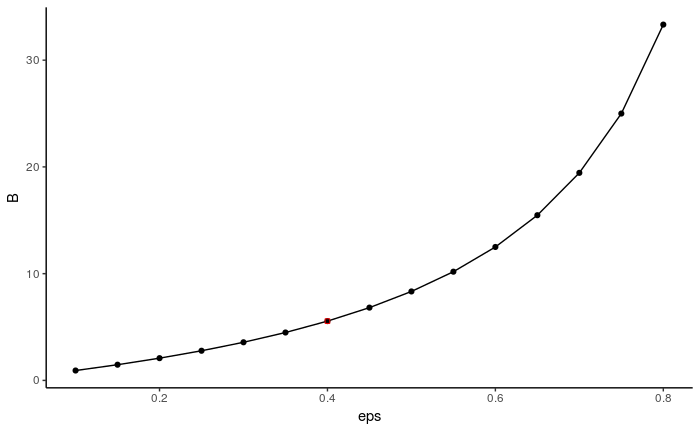

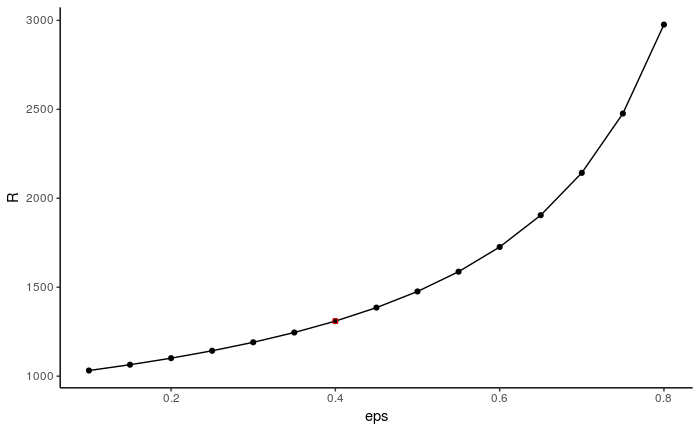

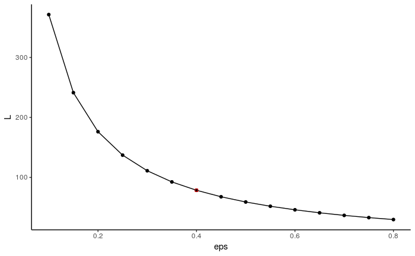

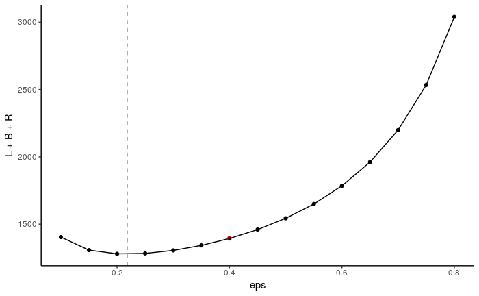

Usually total SOM stocks decrease with decreasing CUE. Only for very low CUE they increae again because of accumualtion of undecomposed litter. This increase is more prominent with decreasing turnover rate of litter pool, $k_L$, in relation to $k_R$.